# warmup02-sam-na

# Vectors

```r
planets <- c("Mercury", "Venus", "Earth", "Mars", "Jupiter", "saturn", "Uranus", "Neptune")
mass <- c(0.33, 4.87, 5.97, 0.642, 1898, 568, 86.8, 102)
diameter <- c(4879, 12104, 12756, 6792, 142984, 120536, 51118, 49528)
density <- c(5427, 5243, 5514, 3933, 1326, 687, 1271, 1638)
gravity <-c(3.7, 8.9, 9.8, 3.7, 23.1, 9, 8.7, 11)
daylength <- c(4222.6, 2802, 24, 24.7, 9.9, 10.7, 17.2, 16.1)
temperature <- c(167, 464, 15, -65, -110, -140, -195, -200)
pressure <- c(0, 92, 1, 0.01, NA, NA, NA, NA)
moons <-c(0, 0, 1, 2, 79, 62, 27, 14)
rings <- c("No", "No", "No", "No", "Yes", "Yes", "Yes", "Yes")
```

# Descriptive Summaries

```r
#Minimum Value
mass[which.min(mass)]
```

```
## [1] 0.33
```

```r
#First Quartile
quantile(mass)[2]
```

```
##   25%
## 3.813
```

```r
#Median
quantile(mass)[3]
```

```
##    50%
## 46.385
```

```r
#Mean
mean(mass)
```

```
## [1] 333.3265
```

```r
#Third Quartile
quantile(mass)[4]
```

```
##   75%
## 218.5
```

```r
#90th Percentile
quantile(mass, .9)
```

```
## 90%
## 967
```

```r
#Maximum Value
mass[which.max(mass)]
```

```
## [1] 1898
```

```r
#IQR
IQR(mass)
```

```
## [1] 214.687
```

```r
#Standard Deviation
sd(mass)
```

```
## [1] 660.5381
```

# Subscripting

```r
#Name of Heaviest Planet
planets[which.max(mass)]
```

```
## [1] "Jupiter"
```

```r
#Temp of Diameter 6792
temperature[diameter == 6792]
```

```
## [1] -65
```

```r
#Mass of Planet with Most Moons
mass[which.max(moons)]
```

```
## [1] 1898
```

```r
#Num of Moons on Coldest Planet
moons[which.min(temperature)]
```

```
## [1] 14
```

```r
#Frequencies of Rings
table(factor(rings))
```

```
##
##  No Yes
##   4   4
```

```r
#Num of Planets with Density larger than Mean
length(density[density > mean(density)])
```

```
## [1] 4
```

```r
#0-2 Moons
length(moons[moons >= 0 & moons <= 2])
```

```
## [1] 4
```

```r
#Median Number of Moons for Ring Planets
median(moons[rings == "Yes"])
```

```
## [1] 44.5
```

```r
#Mean Daylength of planets with NA pressure
mean(daylength[is.na(pressure)])
```

```
## [1] 13.475
```

```r
#First Quartile of Temp for Planets with Gravity Between 8 and 10
quantile(temperature[gravity >= 8 & gravity <= 10], 0.25)
```

```
##     25%
## -153.75
```

# List for Planets

```r
solar <- list(
  planets = planets,
  mass = mass,
  temperature = temperature,
  moons = moons,
  rings = rings
)
```

```r
#Heaviest Planet
solar$planets[solar$mass == max(solar$mass)]
```

```
## [1] "Jupiter"
```

```r
#Mass of Planet with most Moons
solar$mass[solar$moons == max(solar$moons)]
```

```
## [1] 1898
```

```r
#Count of Planets with Positive Temps
length(solar$planets[solar$temperature > 0])
```

```
## [1] 3
```

```r
#Third Quartile for Temp of Planets with Rings
quantile(solar$temperature[solar$rings == "Yes"], .75)
```

```
##    75%
## -132.5
```

# More Lists

```r
hp <- list(
  first = "Harry",
  last = "Potter",
  courses = c("Potions", "Enchantments", "Spells"),
  sport = "quidditch",
  age = 18L,
  gpa = 3.9
)
```

```r
#Class
class(hp)
```

```
## [1] "list"
```

```r
#Elements
length(hp)
```

```
## [1] 6
```

```r
#Length of Courses
length(hp$courses)
```

```
## [1] 3
```

```r
#Data Type of age
typeof(hp$age)
```

```
## [1] "integer"
```

```r
#Data Type of gpa
typeof(hp$gpa)
```

```
## [1] "double"
```

```r
#Type of gpa and age together
typeof(c(hp$gpa, hp$age))
```

```
## [1] "double"
```

# Factors

```r
brks <- c(2900, 3500, 4000, 4500, 5000, 5500, 6000, 6500, 7000)
lbls <- c("<3.5k", "3.5k-4k", "4k-4.5k", "4.5k-5k", "5k-5.5k", "5.5k-6k", "6k-6.5k", "6.5k-7k")
income <- cut(state.x77[,2], breaks = brks, labels = lbls, right = TRUE)
table(income)
```

```
## income
##   <3.5k 3.5k-4k 4k-4.5k 4.5k-5k 5k-5.5k 5.5k-6k 6k-6.5k 6.5k-7k
##       2      11      11      18       7       0       1       0
```

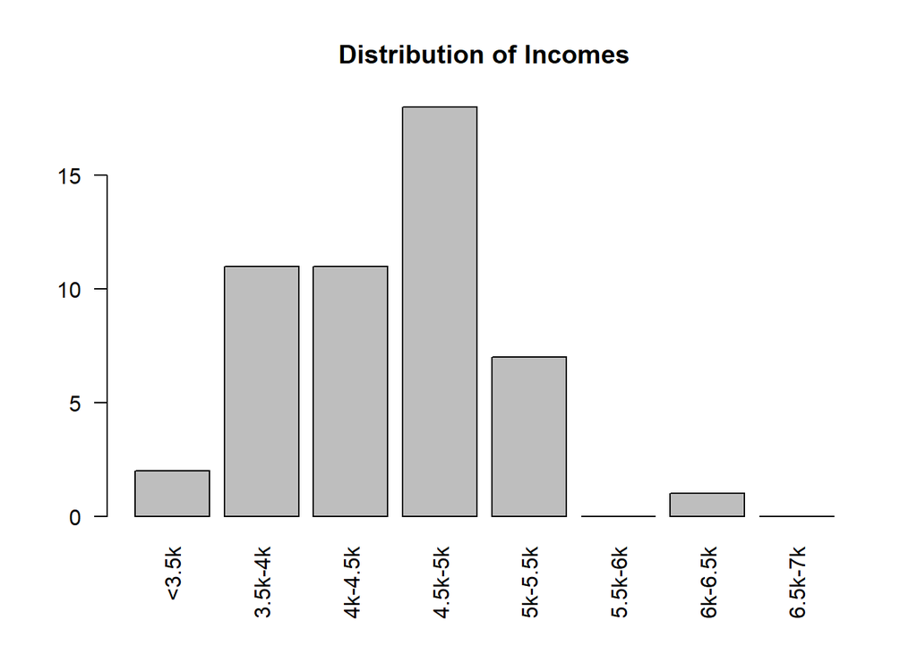

```r
barplot(table(income), names.arg = lbls, las = 2, main = "Distribution of Incomes")
```

# Technical Questions

```r
x <- c(1, 2, 3, 4, 5)
y <- c("a", "b", "c", "d", "e")
y[x[-2][3]]
```

```
## [1] "d"
```

### a) This subsets y to just the elements that correspond to the elements in x that are less than or equal to two (elements 1 and 2).

### b) This subsets y to the element that correspond to the element in x that matches the fifth element in x (element 5).

### c) This subsets y to the elements that correspond to the elements in x that do not fulfill the conditional “x < 3” (elements 3, 4, and 5).

### d) This returns the elements in y that match the element numbers given by x/x (which returns a list of five 1’s), therefore resulting in a list of five a’s.

### e) This returns the element in y that match the element number given by x[-2][3] (the [-2] cuts the second number in the list, resulting in x <- c(1, 2, 4, 5), and the [3] results in 4, now the third element in this list) which gives us “d”.

### f) This subsets x to the elements which correspond to the elements in y which aren’t “c” or “a” (“b”, “d”, and “e”), which gives us 2, 4, and 5.

# 2D Arrays

```r
lord <- c("v", "o", "l", "d", "e", "m", "o", "r", "t")
vol <-matrix(lord, nrow = 3, ncol = 3)
vol
```

```
##      [,1] [,2] [,3]
## [1,] "v"  "d"  "o"
## [2,] "o"  "e"  "r"
## [3,] "l"  "m"  "t"
```

```r
#A
vol[1,]
```

```
## [1] "v" "d" "o"
```

```r
#B
cbind(vol[1:2, 2], vol[1:2, 1])
```

```
##      [,1] [,2]
## [1,] "d"  "v"
## [2,] "e"  "o"
```

```r
#C
vol[3:1, ]
```

```
##      [,1] [,2] [,3]
## [1,] "l"  "m"  "t"
## [2,] "o"  "e"  "r"
## [3,] "v"  "d"  "o"
```

```r
#D
cbind(vol[, 1:2], vol[, 2])
```

```
##      [,1] [,2] [,3]
## [1,] "v"  "d"  "d"
## [2,] "o"  "e"  "e"
## [3,] "l"  "m"  "m"
```

```r
#E
vol[3:1, 3:1]
```

```
##      [,1] [,2] [,3]
## [1,] "t"  "m"  "l"
## [2,] "r"  "e"  "o"
## [3,] "o"  "d"  "v"
```

```r
#F
cbind(rbind(vol[3:1, 3:2], vol[1:3, 3:2]), rbind(vol[3:1, 2:3], vol[1:3, 2:3]))
```

```
##      [,1] [,2] [,3] [,4]
## [1,] "t"  "m"  "m"  "t"
## [2,] "r"  "e"  "e"  "r"
## [3,] "o"  "d"  "d"  "o"
## [4,] "o"  "d"  "d"  "o"
## [5,] "r"  "e"  "e"  "r"
## [6,] "t"  "m"  "m"  "t"
```

```r
#G
cbind(rbind(vol[3:1, 1:3], vol), rbind(vol[3:1, 3:1], vol[, 3:1]))
```

```
##      [,1] [,2] [,3] [,4] [,5] [,6]
## [1,] "l"  "m"  "t"  "t"  "m"  "l"
## [2,] "o"  "e"  "r"  "r"  "e"  "o"
## [3,] "v"  "d"  "o"  "o"  "d"  "v"
## [4,] "v"  "d"  "o"  "o"  "d"  "v"
## [5,] "o"  "e"  "r"  "r"  "e"  "o"
## [6,] "l"  "m"  "t"  "t"  "m"  "l"
```

# Typesetting Mathematics

## Quadratic Equation (General Form)

The quadratic equation is any equation having this form, where $x$ represents and unknown and $a, b,$ and $c$ represent known numbers.
$$ax^{2} + bx + c = 0$$

## Quadratic Equation (Root Form)

$$x = \frac{-b \pm \sqrt{b^{2}-4ac}}{2a}$$

## Derivative of Quadratic Equation

$$ax^{2}+bx + c = 0$$
$$4a^{2}x^{2} + 4abx +4ac = 0$$
$$4a^{2}x^{2} + 4abx = -4ac$$
$$4a^{2}x^{2} + 4abx + b^{2} = b^{2} -4ac$$
$$(2ax+b)^{2} = b^{2}-4ac$$
$$2ax+b = \pm \sqrt{b^{2}-4ac}$$
$$2ax = -b \pm \sqrt{b^{2} -4ac}$$
$$x = \frac{-b \pm \sqrt{b^{2}-4ac}}{2a}$$